# Evaluación de riesgo a la salud (Ejemplo de código de R )

Willebaldo Mantilla Rios

2023-05-23

# Introduccion

En el presente estudio se llevó a cabo un seguimiento del análisis de los efectos a la salud provocados por la fábrica Tarkett, la cual se dedica a la manipulación de vinil. En esta ocasión, se examinaron los síntomas manifestados por los habitantes cercanos a la fábrica, considerando la variable de que la fábrica se encuentra en operación. El propósito del estudio fue buscar casos activos de enfermedades relacionadas con la contaminación generada durante la operación de la fábrica. Los resultados de este estudio permitirán tener una mejor comprensión sobre los efectos de la contaminación en la salud de las personas que viven cerca de fábricas y otras actividades industriales. De esta forma, se podrán tomar medidas preventivas para proteger la salud de la población.

# Objetivos:

Determinar si la reapertura de la fábrica está relacionada con un aumento en los casos de síntomas respiratorios, dermatológicos y otros problemas de salud en la población cercana a la fábrica.

# Analisis

Los síntomas evaluados en el estudio se agruparon en cinco categorías: dermatológicos, oculares, respiratorios, gastrointestinales y otros. A continuación, se presenta un resumen de los síntomas y sus respectivas incidencias en la población estudiada:

## Crear una Tabla

En el siguiente ejemplo de codigo se genera una tabla utilizando el paquete KableExtra y dplyr:

```r
#Utilizamos  warning=FALSE para eliminar los avisos en el reporte.

# Se utiliza suppressMessages para eliminar o suprimir los warning en el reporte de Rmarkdown y presentar un reporte limpio:

suppressMessages(library(kableExtra))
suppressMessages(library(dplyr))

#Creamos el dataframe:
sintomas_data <- data.frame(
  Variable = c("Erupción cutánea", "Eritema", "Prurito",
               "Lagrimeo", "Irritación",
               "Tos", "Congestión nasal", "Irritación de garganta", "Escurrimiento nasal", "Dolor de cabeza",
               "Náuseas", "Vómito",
               "Hormigueo en brazos", "Hormigueo en piernas", "Cansancio mayor a lo habitual", "Sensación de pesadez de piernas", "Mareo", "Pérdida de apetito", "Insomnio"),
  N = c(18, 14, 14, 26, 41, 31, 44, 44, 32, 33, 7, 4, 6, 4, 19, 6, 15, 5, 19),
  Porcentaje = c(23.7, 18.4, 18.4, 34.2, 53.9, 40.8, 57.9, 57.9, 42.1, 43.4, 9.2, 5.3, 7.9, 5.3, 25, 7.9, 19.7, 6.6, 25)
)


# Acomodamos por categorías al data frame: sintomas_data
sintomas_data$Categoria <- c(
  rep("Sintomas Dermatologicos", 3),
  rep("Sintomas Oculares", 2),
  rep("Sintomas Respiratorios", 5),
  rep("Sintomas Gastrointestinales", 2),
  rep("Otros", 7)
)

# Reorganizamos las columnas
sintomas_data <- sintomas_data[, c("Categoria", "Variable", "N", "Porcentaje")]

sintomas_data <- sintomas_data %>%
  group_by(Categoria) %>%
  mutate(Categoria = ifelse(row_number() == 1, Categoria, "")) %>%
  ungroup()


# Crear la tabla con el formato con el estilo seleccionado :striped
sintomas_kable <- sintomas_data %>%
  kable("simple", col.names = c("Categoría", "Síntoma", "N", "%")) %>%
  kable_styling(bootstrap_options = c("striped", "hover"))

# Personalizamos con etiquetas de las categorías a la tabla
sintomas_kable <- sintomas_kable %>%
  pack_rows("Sintomas Dermatologicos", 1, 3) %>%
  pack_rows("Sintomas Oculares", 4, 5) %>%
  pack_rows("Sintomas Respiratorios", 6, 10) %>%
  pack_rows("Sintomas Gastrointestinales", 11, 12) %>%
  pack_rows("Otros", 13, 19)
#Visualizamos la tabla:
sintomas_kable
```

| Categoría | Síntoma | N | % |
| --- | --- | --- | --- |
| Sintomas Dermatologicos | Erupción cutánea | 18 | 23.7 |
|  | Eritema | 14 | 18.4 |
|  | Prurito | 14 | 18.4 |
| Sintomas Oculares | Lagrimeo | 26 | 34.2 |
|  | Irritación | 41 | 53.9 |
| Sintomas Respiratorios | Tos | 31 | 40.8 |
|  | Congestión nasal | 44 | 57.9 |
|  | Irritación de garganta | 44 | 57.9 |
|  | Escurrimiento nasal | 32 | 42.1 |
|  | Dolor de cabeza | 33 | 43.4 |
| Sintomas Gastrointestinales | Náuseas | 7 | 9.2 |
|  | Vómito | 4 | 5.3 |
| Otros | Hormigueo en brazos | 6 | 7.9 |
|  | Hormigueo en piernas | 4 | 5.3 |
|  | Cansancio mayor a lo habitual | 19 | 25.0 |
|  | Sensación de pesadez de piernas | 6 | 7.9 |
|  | Mareo | 15 | 19.7 |
|  | Pérdida de apetito | 5 | 6.6 |
|  | Insomnio | 19 | 25.0 |

## Analsis de sintomas mediante cluster

```r
# analsis de sintomas

#Cargar e instalar varios paquetes y dependencias:
ipak <- function(pkg){
  new.pkg <- pkg[!(pkg %in% installed.packages()[, "Package"])]
  if (length(new.pkg))
    install.packages(new.pkg, dependencies = TRUE)
  sapply(pkg, require, character.only = TRUE)
}

packages <- c("fpc","NbClust","cluster","factoextra","tidyr")
ipak(packages)
```

```
##        fpc    NbClust    cluster factoextra      tidyr
##       TRUE       TRUE       TRUE       TRUE       TRUE
```

```r
library(readxl)
```

```r
library(dplyr)
library(ggstatsplot)
library(ggplot2)
library(stats)
library(NbClust)

#datos:
df <- data.frame(
  Sintomas = c(
    "Erupcion cutanea",
    "Eritema",
    "Prurito",
    "Lagrimeo",
    "Irritacion",
    "Tos",
    "Congestion nasal",
    "Irritacion de garganta",
    "Escurrimiento nasal",
    "Dolor de cabeza",
    "Nauseas",
    "Vomito",
    "Hormigueo en brazos",
    "Hormigueo en piernas",
    "Cansancio mayor a lo habitual",
    "Sensación de pesadez de piernas",
    "Mareo",
    "Perdida de apetito",
    "Insomnio"
  ),
  Casos = c(
    18, 14, 14, 26, 41, 31, 44, 44, 32, 33, 7, 4, 6, 4, 19, 6, 15, 5, 19
  )
)



#paso 1 estandarizar base de datos
df_standardized <- scale(df[, -1])

#paso 2  Asignar los nombres de las variables a la base de datos estandarizada De esta manera, la base de datos estandarizada df_standardized se puede utilizar en el análisis de clustering, y cuando se quiera hacer referencia a las variables originales, se pueden utilizar los nombres de columna que se han asignado en lugar de simplemente referirse a las columnas por su posición numérica.
colnames(df_standardized) <- colnames(df)[-1]

#paso 3  calcular la matriz de distancia

dist_matrix <- dist(df_standardized)

# imprimir la matriz de distancia
print(dist_matrix)
```

```
##             1          2          3          4          5          6          7
## 2  0.28835036
## 3  0.28835036 0.00000000
## 4  0.57670072 0.86505108 0.86505108
## 5  1.65801458 1.94636494 1.94636494 1.08131385
## 6  0.93713867 1.22548904 1.22548904 0.36043795 0.72087590
## 7  1.87427735 2.16262771 2.16262771 1.29757663 0.21626277 0.93713867
## 8  1.87427735 2.16262771 2.16262771 1.29757663 0.21626277 0.93713867 0.00000000
## 9  1.00922626 1.29757663 1.29757663 0.43252554 0.64878831 0.07208759 0.86505108
## 10 1.08131385 1.36966422 1.36966422 0.50461313 0.57670072 0.14417518 0.79296349
## 11 0.79296349 0.50461313 0.50461313 1.36966422 2.45097807 1.73010217 2.66724084
## 12 1.00922626 0.72087590 0.72087590 1.58592699 2.66724084 1.94636494 2.88350361
## 13 0.86505108 0.57670072 0.57670072 1.44175181 2.52306566 1.80218976 2.73932843
## 14 1.00922626 0.72087590 0.72087590 1.58592699 2.66724084 1.94636494 2.88350361
## 15 0.07208759 0.36043795 0.36043795 0.50461313 1.58592699 0.86505108 1.80218976
## 16 0.86505108 0.57670072 0.57670072 1.44175181 2.52306566 1.80218976 2.73932843
## 17 0.21626277 0.07208759 0.07208759 0.79296349 1.87427735 1.15340145 2.09054012
## 18 0.93713867 0.64878831 0.64878831 1.51383940 2.59515325 1.87427735 2.81141602
## 19 0.07208759 0.36043795 0.36043795 0.50461313 1.58592699 0.86505108 1.80218976
##             8          9         10         11         12         13         14
## 2
## 3
## 4
## 5
## 6
## 7
## 8
## 9  0.86505108
## 10 0.79296349 0.07208759
## 11 2.66724084 1.80218976 1.87427735
## 12 2.88350361 2.01845253 2.09054012 0.21626277
## 13 2.73932843 1.87427735 1.94636494 0.07208759 0.14417518
## 14 2.88350361 2.01845253 2.09054012 0.21626277 0.00000000 0.14417518
## 15 1.80218976 0.93713867 1.00922626 0.86505108 1.08131385 0.93713867 1.08131385
## 16 2.73932843 1.87427735 1.94636494 0.07208759 0.14417518 0.00000000 0.14417518
## 17 2.09054012 1.22548904 1.29757663 0.57670072 0.79296349 0.64878831 0.79296349
## 18 2.81141602 1.94636494 2.01845253 0.14417518 0.07208759 0.07208759 0.07208759
## 19 1.80218976 0.93713867 1.00922626 0.86505108 1.08131385 0.93713867 1.08131385
##            15         16         17         18
## 2
## 3
## 4
## 5
## 6
## 7
## 8
## 9
## 10
## 11
## 12
## 13
## 14
## 15
## 16 0.93713867
## 17 0.28835036 0.64878831
## 18 1.00922626 0.07208759 0.72087590
## 19 0.00000000 0.93713867 0.28835036 1.00922626
```

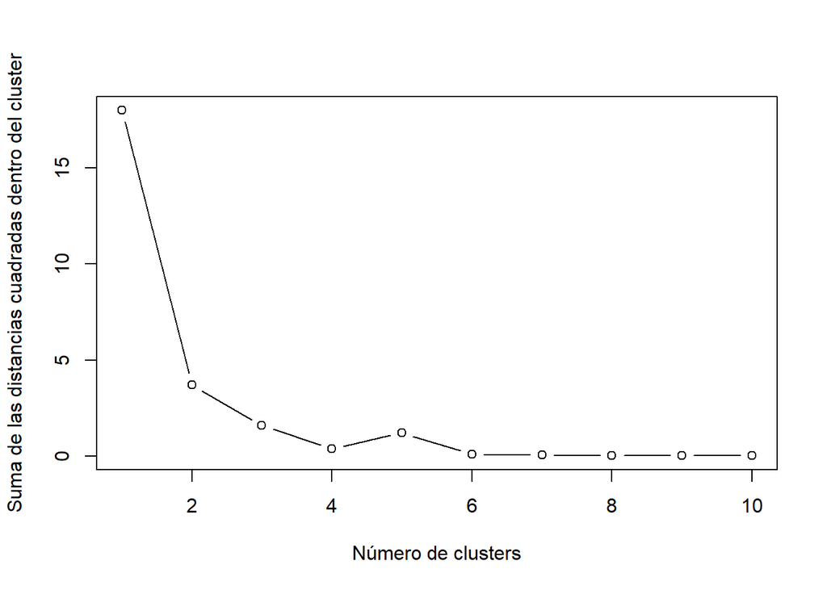

```r
#paso 4estimar el número de clústers
#Método 1 o del codo: Este método implica trazar la suma de las distancias cuadradas dentro del cluster (SSWC) en función del número de clusters. El número de clusters óptimo es el punto en el que la curva comienza a aplanarse o formar un "codo"

# calcular la suma de las distancias cuadradas dentro del cluster (SSWC)
wss <- (nrow(df_standardized) - 1) * sum(apply(df_standardized, 2, var))

# calcular la curva del método del codo
ssd <- c()
for (i in 1:10) {
  fit <- kmeans(df_standardized, i)
  ssd <- c(ssd, fit$tot.withinss)
}

# graficar la curva del método del codo
plot(1:10, ssd, type="b", xlab="Número de clusters", ylab="Suma de las distancias cuadradas dentro del cluster")
```

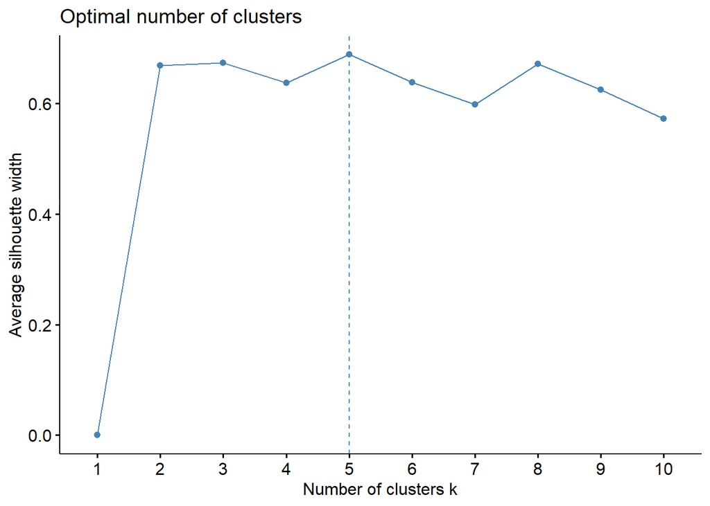

```r
# metodo 2 Método de la silueta: Este método implica calcular la silueta de cada punto en la base de datos estandarizada para diferentes valores de k (número de clusters) y seleccionar el valor de k que produce el valor más alto de silueta promedio. La silueta es una medida de cuán bien se ajusta cada punto a su propio cluster en comparación con los otros clusters.


fviz_nbclust(df_standardized, kmeans, method = "silhouette")
```

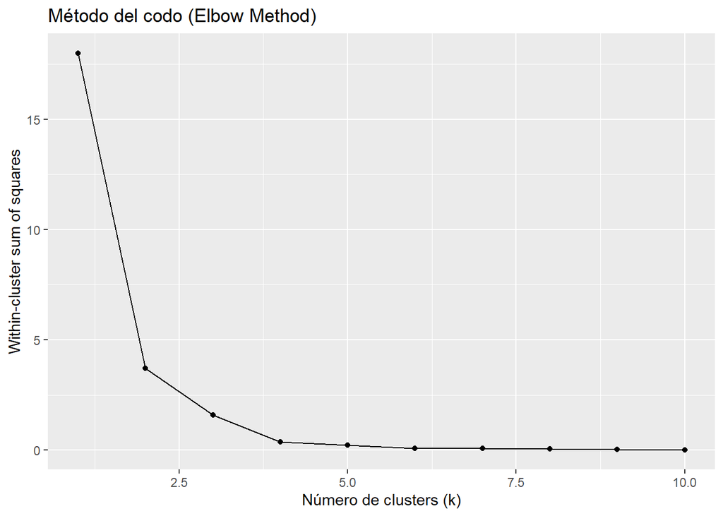

```r
#otro
# Cargar la librería "ggplot2"
library(ggplot2)

# Calcular el valor de "wss" (within-cluster sum of squares) para diferentes números de clusters
wss <- sapply(1:10, function(k) {
  kmeans(df_standardized, k, nstart = 10)$tot.withinss
})

# Graficar el valor de "wss" para diferentes números de clusters
ggplot(data.frame(x = 1:10, y = wss), aes(x, y)) +
  geom_point() +
  geom_line() +
  xlab("Número de clusters (k)") +
  ylab("Within-cluster sum of squares") +
  ggtitle("Método del codo (Elbow Method)")
```

```r
#PASO 5 calculamos los  clústers OPTIMOS obtenidos anteriormente
k2 <- kmeans(df_standardized, centers = 3, nstart = 25)
k2
```

```
## K-means clustering with 3 clusters of sizes 7, 6, 6
##
## Cluster means:
##        Casos
## 1 -0.1620616
## 2  1.2539447
## 3 -1.0648728
##
## Clustering vector:
##  [1] 1 1 1 1 2 2 2 2 2 2 3 3 3 3 1 3 1 3 1
##
## Within cluster sum of squares by cluster:
## [1] 0.55529604 0.98475962 0.03810855
##  (between_SS / total_SS =  91.2 %)
##
## Available components:
##
## [1] "cluster"      "centers"      "totss"        "withinss"     "tot.withinss"
## [6] "betweenss"    "size"         "iter"         "ifault"
```

```r
str(k2)
```

```
## List of 9
##  $ cluster     : int [1:19] 1 1 1 1 2 2 2 2 2 2 ...
##  $ centers     : num [1:3, 1] -0.162 1.254 -1.065
##   ..- attr(*, "dimnames")=List of 2
##   .. ..$ : chr [1:3] "1" "2" "3"
##   .. ..$ : chr "Casos"
##  $ totss       : num 18
##  $ withinss    : num [1:3] 0.5553 0.9848 0.0381
##  $ tot.withinss: num 1.58
##  $ betweenss   : num 16.4
##  $ size        : int [1:3] 7 6 6
##  $ iter        : int 2
##  $ ifault      : int 0
##  - attr(*, "class")= chr "kmeans"
```

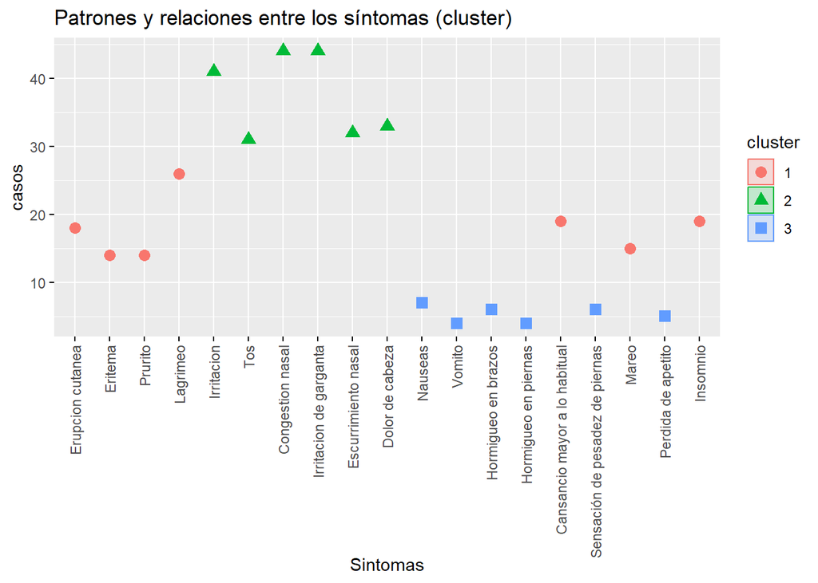

```r
#PASO 6 plotear los cluster
library(factoextra)
library(ggplot2)

kmeans_res <- kmeans(df_standardized, centers = 3, nstart = 25)

fviz_cluster(kmeans_res, data = df, stand = FALSE,
             geom = "point", ellipse.type = "convex") +
  theme(axis.text.x = element_text(angle = 90, vjust = 0.5, hjust=1))+ggtitle("Patrones y relaciones entre los síntomas (cluster)") +
  ylab("casos")
```

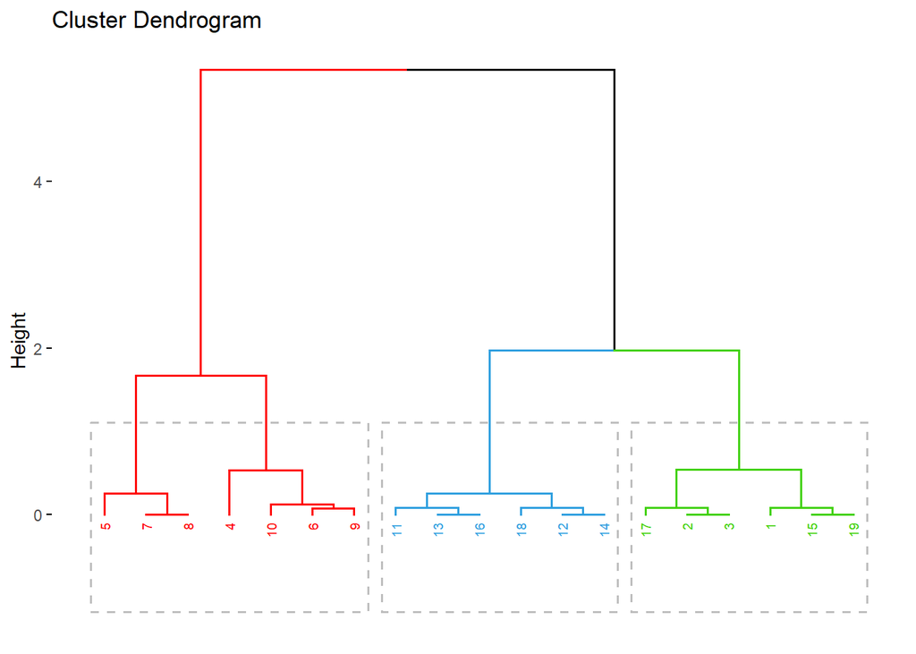

```r
#paso 7 construir un dendograma con los closter calculados
res2 <- hcut(df_standardized, k = 3, stand = TRUE)

fviz_dend(res2, rect = TRUE, cex = 0.5,
          k_colors = c("red","#2E9FDF","#41D107","#E7B800","#B533FF"))
```

```r
#paso 8pasar los cluster a mi df inicial para trabajar con ellos

df %>%
  mutate(Cluster = kmeans_res$cluster) %>%
  group_by(Cluster) %>%
  summarise_all("mean")
```

| Cluster | Sintomas | Casos |
| --- | --- | --- |
| 1 | NA | 17.857143 |
| 2 | NA | 37.500000 |
| 3 | NA | 5.333333 |

## Grafico de barras simple

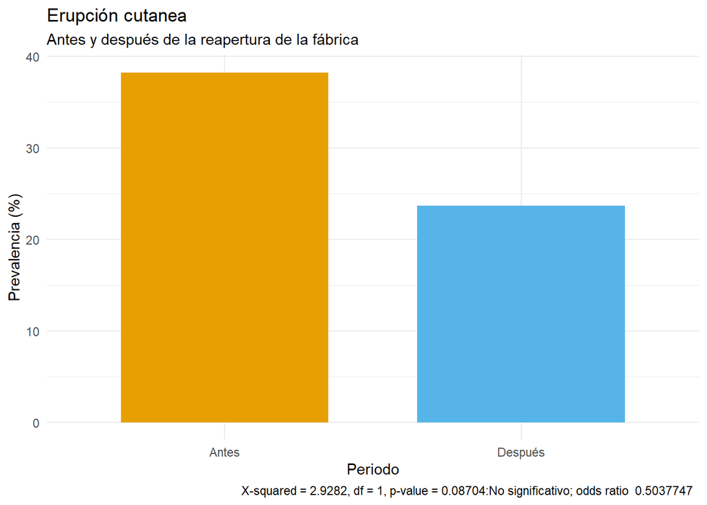

```r
suppressMessages(library(ggplot2))
# ERUPCIÓN CUTANEA
casos_antes <- 26
casos_despues <- 18
poblacion_antes <- 68
poblacion_despues <- 76

# Calcular la incidencia antes y después de la reapertura
incidencia_antes <- (casos_antes / poblacion_antes) * 100
incidencia_despues <- (casos_despues / poblacion_despues) * 100

# Crear un marco de datos
incidencia_df <- data.frame(
  Periodo = c("Antes", "Después"),
  Incidencia = c(incidencia_antes, incidencia_despues)
)

ggplot(data = incidencia_df, aes(x = Periodo, y = Incidencia)) +
  geom_bar(stat = "identity", fill = c("#E69F00", "#56B4E9"), width = 0.7) +
  theme_minimal() +
  labs(
    title = "Erupción cutanea",
    subtitle = "Antes y después de la reapertura de la fábrica",
    x = "Periodo",
    y = "Prevalencia (%)"
  )+labs(caption = "X-squared = 2.9282, df = 1, p-value = 0.08704:No significativo; odds ratio  0.5037747  ")
```

## Analisis entre grupos

El siguiente analsis es una comparacion de grupos (no parametrico) utilizando paquetes como tidyverse y con una base externa:

```r
# analisis de kruskal wallis
#cargamos los paquetes:
library(rstatix)
library(PupillometryR)
library(gtsummary)
library(here)
library(tidyverse)
library(readxl)
library(csvread)

#Cargamos la base de datos almacenadas en un documento externo en excel y le asignamos un nombre o objeto en este caso lo llamaremos Anovapruebas, utilizando readxl:
Anovapruebas <- read_csv("fil.csv")
#se analizan los tipos de datos que contiene la base:
glimpse(Anovapruebas)
```

```
## Rows: 67
## Columns: 3
## $ Ubicacion    <chr> "40mts", "40mts", "40mts", "40mts", "40mts", "40mts", "40…
## $ distancia    <dbl> 1.958784, 3.195052, 5.829294, 7.818374, 7.835193, 8.25444…
## $ Afectaciones <dbl> 3, 2, 2, 4, 3, 2, 5, 5, 2, 2, 2, 3, 3, 5, 4, 4, 4, 3, 3, …
```

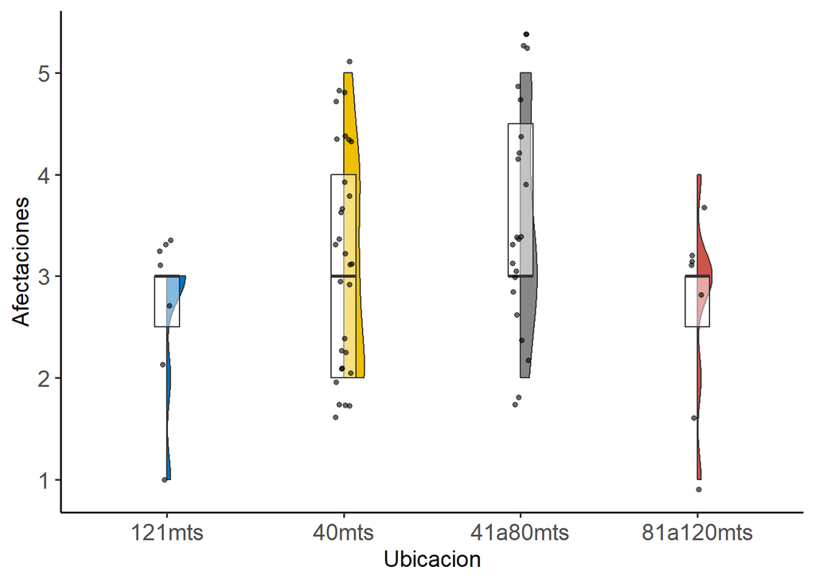

```r
#Convertimos la variable ubicacion a factor utilizando mutate:

Anovapruebas <- Anovapruebas %>%
  mutate( Ubicacion= factor(Ubicacion))



#krus <- (En caso de querer guardar la imagen creamos este objeto) #realizamos el grafico de comparacion de grupos:
ggplot(Anovapruebas, aes(x=Ubicacion, y=Afectaciones)) +
  geom_flat_violin(aes(fill = Ubicacion), scale = "count") +
  geom_boxplot(width = 0.14, outlier.shape = NA, alpha = 0.5) +
  geom_point(position = position_jitter(width = 0.05),
             size = 1.2, alpha = 0.6) +
  ggsci::scale_fill_jco() +
  theme_classic(base_size = 14) +
  theme(legend.position="none",
        axis.text = element_text(size = 14))
```

```r
#Para guardar la grafica utilizamos el siguiente codigo sin el signo de gato o numero, ponemos el nombre del archo y ajustamos las medidas:

#ggsave(krus, filename = "krusdistancias.png", width = 15, height = 9, units = "cm", dpi = 110)


# agrupamos los datos por distancias con dplyr
dis_summary <- Anovapruebas %>%
  group_by(Ubicacion) %>%
  dplyr::summarise(
    n = n(),
    na = sum(is.na(Afectaciones)),
    min = min(Afectaciones, na.rm = TRUE),
    q1 = quantile(Afectaciones, 0.25, na.rm = TRUE),
    median = quantile(Afectaciones, 0.5, na.rm = TRUE),
    q3 = quantile(Afectaciones, 0.75, na.rm = TRUE),
    max = max(Afectaciones, na.rm = TRUE),
    mean = mean(Afectaciones, na.rm = TRUE),
    sd = sd(Afectaciones, na.rm = TRUE),
    skewness = EnvStats::skewness(Afectaciones, na.rm = TRUE),
    kurtosis= EnvStats::kurtosis(Afectaciones, na.rm = TRUE)
  ) %>%
  ungroup()

dis_summary
```

| Ubicacion | n | na | min | q1 | median | q3 | max | mean | sd | skewness | kurtosis |
| --- | --- | --- | --- | --- | --- | --- | --- | --- | --- | --- | --- |
| 121mts | 7 | 0 | 1 | 2.5 | 3 | 3.0 | 3 | 2.571429 | 0.7867958 | -1.7598154 | 2.360947 |
| 40mts | 30 | 0 | 2 | 2.0 | 3 | 4.0 | 5 | 3.166667 | 1.0854312 | 0.3402684 | -1.215501 |
| 41a80mts | 23 | 0 | 2 | 3.0 | 3 | 4.5 | 5 | 3.521739 | 1.0816471 | 0.1749084 | -1.232263 |
| 81a120mts | 7 | 0 | 1 | 2.5 | 3 | 3.0 | 4 | 2.714286 | 0.9511897 | -0.8631849 | 1.244875 |

```r
#prueba de normalidad

Anovapruebas %>%
  group_by(Ubicacion) %>%
  shapiro_test(Afectaciones) %>%
  ungroup()
```

| Ubicacion | variable | statistic | p |
| --- | --- | --- | --- |
| 121mts | Afectaciones | 0.6461875 | 0.0009314465 |
| 40mts | Afectaciones | 0.8432541 | 0.0004493422 |
| 41a80mts | Afectaciones | 0.8558100 | 0.0034735667 |
| 81a120mts | Afectaciones | 0.8693003 | 0.1830279262 |

```r
#como alguno de los grupos el resultado de p es menor 0.05 se considera no nomal

#prueba kruskal wallis

kruskal.test(Afectaciones ~ Ubicacion, data = Anovapruebas)
```

```
##
##  Kruskal-Wallis rank sum test
##
## data:  Afectaciones by Ubicacion
## Kruskal-Wallis chi-squared = 4.7315, df = 3, p-value = 0.1925
```